# Modeling COVID-19 Mortality With Linear Regression

## Introduction

Since February 2020, over 32 million cases of COVID-19 - the disease caused by the SARS-CoV-2 coronavirus - have been reported in the United States. The CDC has been monitoring this situation, gathering data on many cases and publishing it in an anonymized form. However, experts have called into question whether we are doing enough to monitor the spread of the coronavirus. For instance, it is estimated that nearly twice as many people as reported have died of the disease in the U.S. Can we find a way to predict who will die of COVID-19, and can we use such a model to fill in gaps in our knowledge? How many deaths are we missing?

## The Data Science Pipeline

We can answer questions like these through the Data Science Pipeline. It is a standard approach to getting insight out of data. The steps are:

- Data collection, curation and parsing
- Data management and representation
- Exploratory analysis
- Hypothesis testing and/or machine learning
- Communication of insights

Note that this process need not be linear. Insights gathered in a later step of the process may require a reassessment of earlier stages, resulting in a cycle of improvement.

## Data Collection, Curation and Parsing

We will be applying this process to the dataset found here: https://data.cdc.gov/Case-Surveillance/COVID-19-Case-Surveillance-Public-Use-Data/vbim-akqf.

As of May 10, 2021, this dataset contains around 25 million deidentified COVID-19 case reports in 2.9 gigabytes. Let's download it and start breaking it down. Note: this may take a while!

```python
import pandas as pd
import numpy as np
import timeit

start = timeit.default_timer()
covid19 = pd.read_csv("COVID-19_Case_Surveillance_Public_Use_Data.csv")
stop = timeit.default_timer()
print(stop - start) # see how long it took to load
```

```
28.628269862994784
```

```python
covid19.columns
```

```
Index(['cdc_case_earliest_dt ', 'cdc_report_dt', 'pos_spec_dt', 'onset_dt',
       'current_status', 'sex', 'age_group', 'race_ethnicity_combined',
       'hosp_yn', 'icu_yn', 'death_yn', 'medcond_yn'],
      dtype='object')
```

Let's correct that one little mistake - the space at the end of `cdc_case_earliest_dt`:

```python
covid19.rename({"cdc_case_earliest_dt ": "cdc_case_earliest_dt"}, axis = 1, inplace = True)
covid19.columns
```

```
Index(['cdc_case_earliest_dt', 'cdc_report_dt', 'pos_spec_dt', 'onset_dt',
       'current_status', 'sex', 'age_group', 'race_ethnicity_combined',
       'hosp_yn', 'icu_yn', 'death_yn', 'medcond_yn'],
      dtype='object')
```

Much better. Here's what each of these columns means:

- `cdc_case_earliest_dt`: Earlier of the following two dates: clinical date or date received by CDC.
- `cdc_report_dt`: Date case was first reported to the CDC. Deprecated; it is recommended to use `cdc_case_earliest_dt` instead.
- `pos_spec_dt`: Date of first positive specimen collection.
- `onset_dt`: Date of symptom onset in symptomatic cases.
- `current_status`: Whether the case is laboratory-confirmed or probable.
- `sex`: Reported sex of the patient.
- `age_group`: Reported patient age group.
- `race_ethnicity_combined`: Reported race and ethnicity of the patient.
- `hosp_yn`: Was the patient hospitalized?
- `icu_yn`: Was the patient admitted to an intensive care unit?
- `death_yn`: Did the patient die of COVID-19?
- `medcond_yn`: Did the patient have any underlying comorbidity or disease?

There are a number of problems with this data. For one, it is riddled with missing values as well as NaNs. Dates and age groups are represented as strings, not machine-readable objects. Race and ethnicity are represented as text, which would complicate any kind of analysis.

We need a better idea of what we're dealing with. Let's see how many values are strictly NaN - not "Missing" - and in which columns:

```python
covid19.isna().sum()
```

```
cdc_case_earliest_dt              0
cdc_report_dt               2264629
pos_spec_dt                18219251
onset_dt                   13360031
current_status                    0
sex                              19
age_group                        72
race_ethnicity_combined          19
hosp_yn                           0
icu_yn                            0
death_yn                          0
medcond_yn                        0
dtype: int64
```

Alright, so everywhere but in the date fields, NaN is so vanishingly rare that it isn't worth worrying about.

## Data Management/Representation

Most of these columns are categorical; all possible unique values are stated on the CDC website. Let's represent them as boolean dummy variables - for instance, a column that could say "Male," "Female" or "Other" will be split into three mutually-exclusive boolean variables. This will make it easier to work with in later steps - but there's a lot we actually need to break down. Pandas has us covered; we can use [`pd.get_dummies()`](https://pandas.pydata.org/docs/reference/api/pandas.get_dummies.html) to generate most of them. We will also parse our dates and see how many days each case was reported after January 22, 2020.

```python
import datetime

date_columns = ["case_datetime", "case_days", "pos_spec_datetime", "pos_spec_missing", "onset_datetime",
                "onset_missing", "age_group_n"]

def date_info(row):
    case_datetime = pd.to_datetime(row.cdc_case_earliest_dt, format='%Y/%m/%d', errors='coerce')
    case_days = (case_datetime - datetime.datetime(2020, 1, 22)).days # days after the first COVID case in the U.S.
                                                                      # (January 22, 2020)
    pos_spec_datetime = None
    if not pd.isna(row.pos_spec_dt):
        pos_spec_missing = 0
        pos_spec_datetime = pd.to_datetime(row.pos_spec_dt, format='%Y/%m/%d', errors='coerce')
    else:
        pos_spec_missing = 1

    onset_datetime = None
    if not pd.isna(row.onset_dt):
        onset_missing = 0
        onset_datetime = pd.to_datetime(row.onset_dt, format='%Y/%m/%d', errors='coerce')
    else:
        onset_missing = 1

    age_group_n = 0 # we will also add a numeric age group
    if not pd.isna(row.age_group):
        if row.age_group[0] == "0":
            age_group_n = 1
        elif row.age_group[0] == "1":
            age_group_n = 2
        elif row.age_group[0] == "2":
            age_group_n = 3
        elif row.age_group[0] == "4": # no, I did not miss one, this is a quirk in the data
            age_group_n = 4
        elif row.age_group[0] == "5":
            age_group_n = 5
        elif row.age_group[0] == "6":
            age_group_n = 6
        elif row.age_group[0] == "7":
            age_group_n = 7
        elif row.age_group[0] == "8":
            age_group_n = 8

    return pd.Series([case_datetime, case_days, pos_spec_datetime,
                           pos_spec_missing, onset_datetime, onset_missing, age_group_n])

def dummies(df):
    return pd.get_dummies(df[["current_status", "sex", "age_group", "race_ethnicity_combined", "hosp_yn",
                              "icu_yn", "medcond_yn", "death_yn"]],
                          prefix = ["status", "sex", "age", "race", "hosp", "icu", "medcond", "death"])
    # we need to use different prefixes, otherwise we will get multiple columns with the same name

def rebuild(df):

    di = df.apply(date_info, axis = 1)
    di.columns = date_columns
    du = dummies(df)

    return pd.concat([di, du], axis = 1)
```

```python
rebuild(covid19.head(500))
```

|  | case_datetime | case_days | pos_spec_datetime | pos_spec_missing | onset_datetime | onset_missing | age_group_n | status_Laboratory-confirmed case | status_Probable Case | sex_Female | ... | icu_Unknown | icu_Yes | medcond_Missing | medcond_No | medcond_Unknown | medcond_Yes | death_Missing | death_No | death_Unknown | death_Yes |
| --- | --- | --- | --- | --- | --- | --- | --- | --- | --- | --- | --- | --- | --- | --- | --- | --- | --- | --- | --- | --- | --- |
| 0 | 2020-07-01 | 161 | NaT | 1 | 2020-07-01 | 0 | 0 | 1 | 0 | 0 | ... | 0 | 0 | 1 | 0 | 0 | 0 | 0 | 1 | 0 | 0 |
| 1 | 2020-10-11 | 263 | NaT | 1 | 2020-10-11 | 0 | 2 | 1 | 0 | 1 | ... | 0 | 0 | 1 | 0 | 0 | 0 | 0 | 1 | 0 | 0 |
| 2 | 2021-02-09 | 384 | 2021-02-04 | 0 | 2021-02-10 | 0 | 5 | 0 | 1 | 0 | ... | 0 | 0 | 0 | 0 | 1 | 0 | 1 | 0 | 0 | 0 |
| 3 | 2020-07-20 | 180 | NaT | 1 | NaT | 1 | 0 | 1 | 0 | 1 | ... | 0 | 0 | 1 | 0 | 0 | 0 | 1 | 0 | 0 | 0 |
| 4 | 2020-06-05 | 135 | NaT | 1 | 2020-06-05 | 0 | 1 | 1 | 0 | 0 | ... | 0 | 0 | 1 | 0 | 0 | 0 | 0 | 1 | 0 | 0 |
| ... | ... | ... | ... | ... | ... | ... | ... | ... | ... | ... | ... | ... | ... | ... | ... | ... | ... | ... | ... | ... | ... |
| 495 | 2020-07-10 | 170 | 2020-12-07 | 0 | NaT | 1 | 8 | 1 | 0 | 1 | ... | 0 | 0 | 1 | 0 | 0 | 0 | 0 | 1 | 0 | 0 |
| 496 | 2021-04-09 | 443 | NaT | 1 | NaT | 1 | 0 | 1 | 0 | 0 | ... | 0 | 0 | 1 | 0 | 0 | 0 | 0 | 1 | 0 | 0 |
| 497 | 2020-10-26 | 278 | NaT | 1 | 2020-10-26 | 0 | 1 | 1 | 0 | 1 | ... | 0 | 0 | 1 | 0 | 0 | 0 | 0 | 1 | 0 | 0 |
| 498 | 2020-11-03 | 286 | NaT | 1 | 2020-11-03 | 0 | 2 | 1 | 0 | 1 | ... | 0 | 0 | 1 | 0 | 0 | 0 | 0 | 1 | 0 | 0 |
| 499 | 2021-01-07 | 351 | NaT | 1 | NaT | 1 | 3 | 0 | 1 | 1 | ... | 1 | 0 | 0 | 0 | 1 | 0 | 0 | 0 | 1 | 0 |

500 rows × 47 columns

```python
# rebuild(covid19)
# DO NOT DO THIS!!!!! WE ARE DEALING WITH 2.9 GB DATA, THIS WILL TAKE FOREVER.
```

We have almost 3 GB of data and we want to reprocess it using Python. Doing it all at once is out of the question (I tried it, it took 15 minutes even with maximum parallelism on a 12-core Ryzen 9 and that's before it overheated). Let's work smarter, not harder: we are only going to be looking at random samples anyway, so let's take a sample and reprocess it on the fly.

```python
sample = rebuild(covid19.sample(n = 100000))
```

With that out of the way, it's time for...

## Exploratory Data Analysis

This is the stage where we try to figure out what lines of inquiry are worth investigating. Recall that we wanted to find correlations within our data; we want to know how we can best predict death from COVID-19.

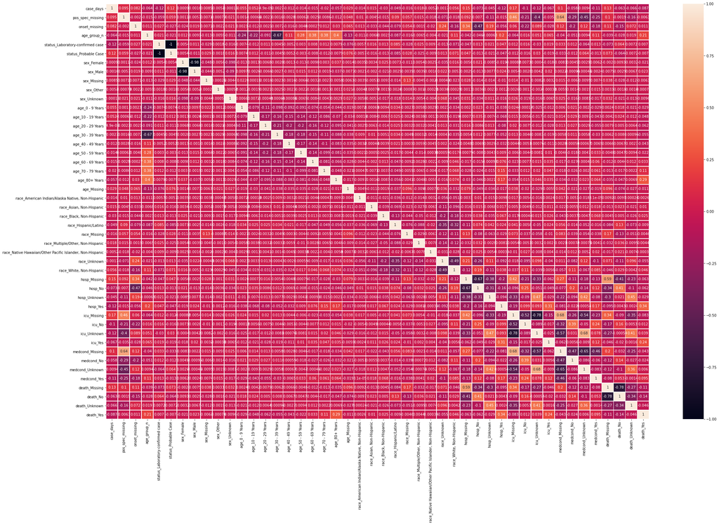

```python
import matplotlib.pyplot as plt
import seaborn as sb

plt.subplots(figsize = (35, 22))
matrix = sb.heatmap(sample\
                    .corr("pearson"), annot = True, linewidths = 0.5)
```

# Wow, that's a lot!

Open the image in a new tab and zoom in if you have to. Let's break it down:

- Some correlations appear quite strong but are actually artifacts of our data - for instance, those between the various age group booleans and `age_group_n`, our numeric representation of age, between `hosp_no` and `icu_no`, and between `hosp_missing` and `icu_missing` (ICU's are inside hospitals after all). Let's be careful to identify only meaningful correlations.
- The strongest correlations with known death were hospitalization, pre-existing conditions, ICU admission and age.
- The strongest correlations with known survival were non-hospitalization, non-admission to the ICU, lack of pre-existing conditions and being Hispanic/Latino. ([Data suggests the COVID-19 death rate is higher for Latinos](https://salud-america.org/coronavirus-case-rates-and-death-rates-for-latinos-in-the-united-states/), so this is probably statistical noise.)

Let's do one more correlation matrix, this time only for patients who are known to have survived or not - the data we will use to train our model. Good thing you can index dataframes using conditional expressions, returning all the rows that meet that condition.

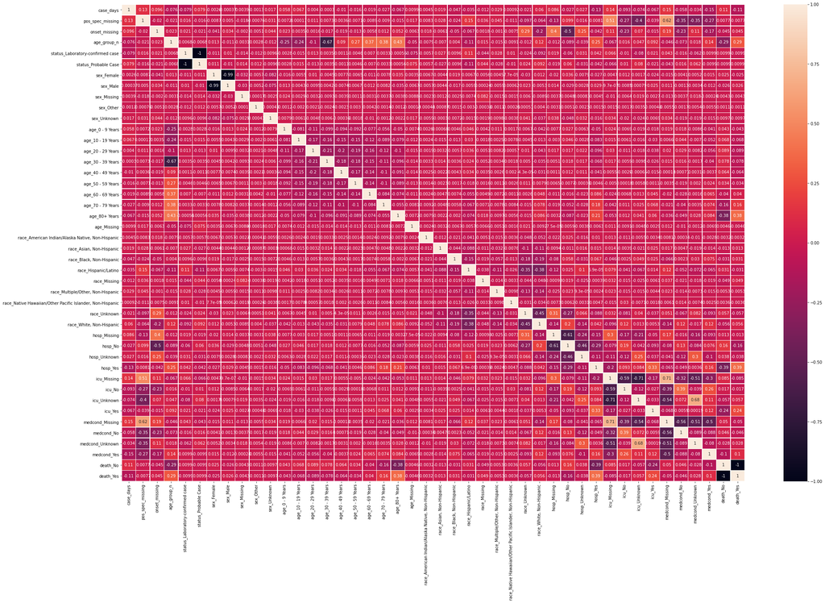

```python
sample_training = rebuild(covid19[(covid19.death_yn == "Yes") | (covid19.death_yn == "No")]\
                                   .sample(n = 100000))

plt.subplots(figsize = (35, 22))
matrix = sb.heatmap(sample_training.corr("pearson"), annot = True, linewidths = 0.5)
```

Now what do we see?

- The correlation between being Latino and surviving COVID-19 has disappeared.
- The strongest positive correlations with death are:
  - Age - either numeric representation or higher dummy variables
  - Hospitalization
  - ICU admission
- The only interesting negative correlations are:
  - Not being hospitalized
  - Days into the pandemic
- And neither of those are strong enough to warrant inclusion in our model. Fewer variables is better.

These are the variables we will use for:

## Hypothesis Testing and Machine Learning

What is a hypothesis? In the scientific method, a hypothesis is a possible explanation for an observed phenomenon. Crucially, it must be *testable* - it must be possible to determine through experimentation whether the hypothesis holds or not. In data science, we have a method called *hypothesis testing* which applies statistics to do just that!

For hypothesis testing, we need a stronger definition of a hypothesis. First, we need a *null hypothesis* - the opposite of our *alternative hypothesis* which assumes our explanation to be false. In addition, we need a *confidence level*, which is a numerical representation of how confident we need to be in our model to reject the null hypothesis. We will use a confidence level of 95% - our *significance level* will be 100% - our confidence level = 0.05. To be clear:

- Null hypothesis: There is no relationship between our selected variables and death from COVID-19
- Alternative hypothesis: There is a relationship between our selected variables and death from COVID-19
- We must be 95% confident in our findings to reject the null hypothesis

We want to test which of these variables are significant, and to do that, we will make a [linear regression model](https://www.statsmodels.org/stable/generated/statsmodels.regression.linear_model.OLS.html). Not only will this allow us to test our hypothesis, it will serve as a predictor for COVID-19 death. This is easy to do in Python. The exact mathematical details of this process are unimportant, although [you can see the Wikipedia article to learn more.](https://en.wikipedia.org/wiki/Polynomial_regression)

## NOTE: THIS APPROACH, WHILE INTUITIVELY CORRECT, IS DANGEROUSLY WRONG AND LEADS TO JUNK RESULTS. IT IS INCLUDED FOR PURPOSES OF DISCUSSION AND I WILL SHOW YOU A BETTER WAY LATER.

```python
from statsmodels.formula.api import ols

model = ols("death_Yes ~ age_group_n + hosp_Yes + icu_Yes", sample_training).fit()
model.summary()
```

OLS Regression Results

| Dep. Variable: | death_Yes | R-squared: | 0.207 |
| --- | --- | --- | --- |
| Model: | OLS | Adj. R-squared: | 0.207 |
| Method: | Least Squares | F-statistic: | 8697. |
| Date: | Fri, 14 May 2021 | Prob (F-statistic): | 0.00 |
| Time: | 21:46:16 | Log-Likelihood: | 38336. |
| No. Observations: | 100000 | AIC: | -7.666e+04 |
| Df Residuals: | 99996 | BIC: | -7.663e+04 |
| Df Model: | 3 |  |  |
| Covariance Type: | nonrobust |  |  |

|  | coef | std err | t | P>\|t\| | [0.025 | 0.975] |
| --- | --- | --- | --- | --- | --- | --- |
| Intercept | -0.0385 | 0.001 | -40.257 | 0.000 | -0.040 | -0.037 |
| age_group_n | 0.0163 | 0.000 | 69.094 | 0.000 | 0.016 | 0.017 |
| hosp_Yes | 0.2238 | 0.002 | 98.292 | 0.000 | 0.219 | 0.228 |
| icu_Yes | 0.2655 | 0.006 | 41.890 | 0.000 | 0.253 | 0.278 |

| Omnibus: | 77316.289 | Durbin-Watson: | 1.996 |
| --- | --- | --- | --- |
| Prob(Omnibus): | 0.000 | Jarque-Bera (JB): | 1594250.471 |
| Skew: | 3.657 | Prob(JB): | 0.00 |
| Kurtosis: | 21.142 | Cond. No. | 52.2 |

Warnings:  
[1] Standard Errors assume that the covariance matrix of the errors is correctly specified.

Let's generate some test data:

```python
sample_testing = rebuild(covid19[(covid19.death_yn == "Yes") | (covid19.death_yn == "No")]\
                                   .sample(n = 100000))
```

Note: When our model outputs a value of 0.5 or greater, it predicts the patient will die of COVID-19. Less than that and it predicts the patient will survive.

```python
def predict_death(x):
    return [1 if i >= 0.5 else 0 for i in model.predict(x)]

sample_testing["pred"] = predict_death(sample_testing)
```

Let's generate a 2x2 heat map - a *confusion matrix* - to see how we did. The confusion matrix will tell us:

- How many true positives (model predicted death, patient died)
- How many true negatives (model predicted survival, patient survived)
- How many false positives (model predicted death, patient survived)
- And how many false negatives (model predicted survival, patient died)

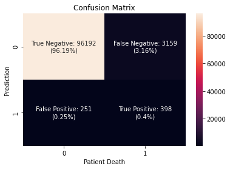

```python
def confusion(df):
    total = df.shape[0] # this gets the number of rows
    true_positive = df[(df.death_Yes == 1) & (df.pred == 1)].shape[0]
    true_negative = df[(df.death_No == 1) & (df.pred == 0)].shape[0]
    false_positive = df[(df.death_No == 1) & (df.pred == 1)].shape[0]
    false_negative = df[(df.death_Yes == 1) & (df.pred == 0)].shape[0]

    confusion = pd.DataFrame([[true_negative, false_negative], [false_positive, true_positive]])

    labels = [[f"True Negative: {true_negative}\n({round(((true_negative / total) * 100), 2)}%)",
               f"False Negative: {false_negative}\n({round(((false_negative / total) * 100), 2)}%)"],
              [f"False Positive: {false_positive}\n({round(((false_positive / total) * 100), 2)}%)",
               f"True Positive: {true_positive}\n({round(((true_positive / total) * 100), 2)}%)"]]

    plot = sb.heatmap(confusion, annot = labels, fmt = "")
    plt.xlabel("Patient Death")
    plt.ylabel("Prediction")
    plt.title("Confusion Matrix")
    plt.show()

    return true_positive, true_negative, false_positive, false_negative

tp, tn, fp, fn = confusion(sample_testing)
```

It's not looking good for our model. Let's take some metrics that can help us diagnose it. These are:

- Error rate - the portion of predictions that were incorrect (accuracy is 1 - error rate)
- Sensitivity - the portion of positives that are correctly detected
- Specificity - the portion of negatives that are correctly detected

```python
error_rate = (fp + fn) / sample_testing.shape[0]
accuracy = 1 - error_rate
sensitivity = tp / (tp + fn)
specificity = tn / (tn + fp)
metrics = pd.DataFrame([error_rate, accuracy, sensitivity, specificity],
                       index = ["Error Rate", "Accuracy",
                                "Sensitivity", "Specificity"],
                       columns = ["Initial Model"])
metrics
```

|  | Initial Model |
| --- | --- |
| Error Rate | 0.034100 |
| Accuracy | 0.965900 |
| Sensitivity | 0.111892 |
| Specificity | 0.997397 |

Our model shows good specificity and accuracy but bad sensitivity. In this case, accuracy is meaningless as it could be very accurate just by guessing everyone survives. [You would rather be told you are at risk and not die (a type I error) than be told you are not at risk and then die (a type II error)](https://en.wikipedia.org/wiki/Type_I_and_type_II_errors#Application_domains), right? This model is more prone to type II errors, so it is not a very good model. In fact, had we paid attention earlier to that report, we would have seen that the R-squared value was low, meaning our model could only account for that much variation in the data. What went wrong?

## A Bit About Bias (Say That Ten Times Fast)

Let's take one more look at our training sample:

```python
print(f"Survivors:\t{sample_training.death_No.sum()}")
print(f"Deaths:\t\t{sample_training.death_Yes.sum()}")
print(f"Death rate:\t{round((sample_training.death_Yes.sum() / sample_training.shape[0] * 100), 2)}%")
```

```
Survivors:	96444
Deaths:		3556
Death rate:	3.56%
```

Our training data is clearly *biased* - COVID-19, while much more deadly than the flu, still has a high survival rate in the absolute sense. We can expect that the vast majority of patients in any **random sample** will have survived COVID-19. Note the emphasis on "random sample" - that is precisely our issue. **Do not fall into the trap of believing a random sample implies an unbiased sample!** Biased training data will produce a biased model. Testing that biased model on biased test data will not make that bias apparent to you unless you know where to look; note that even on our first attempt, accuracy was deceptively high.

We need to train our model using test data that is evenly split between survivors and deaths. This will make our model far better at predicting deaths correctly by reducing false negatives, although there will be a large (but consistent) false positive rate. In a clinical setting, it is better to err on the side of caution. We are choosing to make a trade-off in favor of type I errors.

## Hypothesis Testing and Machine Learning, Attempt 2

```python
death_known_yes = rebuild(covid19[covid19.death_yn == "Yes"].sample(50000))
death_known_no = rebuild(covid19[covid19.death_yn == "No"].sample(50000))
sample_training_balanced = pd.concat([death_known_yes, death_known_no], axis = 0)
sample_training_balanced.death_Yes = sample_training_balanced.death_Yes.fillna(0) # there will be NaN's here,
sample_training_balanced.death_No = sample_training_balanced.death_No.fillna(0)   # but the other value will be 1
                                                                                  # easily replace NaN with 0
```

```python
model_2 = ols("death_Yes ~ age_group_n + hosp_Yes + icu_Yes", sample_training_balanced).fit()
model_2.summary()
```

OLS Regression Results

| Dep. Variable: | death_Yes | R-squared: | 0.582 |
| --- | --- | --- | --- |
| Model: | OLS | Adj. R-squared: | 0.582 |
| Method: | Least Squares | F-statistic: | 4.647e+04 |
| Date: | Fri, 14 May 2021 | Prob (F-statistic): | 0.00 |
| Time: | 21:47:51 | Log-Likelihood: | -28928. |
| No. Observations: | 100000 | AIC: | 5.786e+04 |
| Df Residuals: | 99996 | BIC: | 5.790e+04 |
| Df Model: | 3 |  |  |
| Covariance Type: | nonrobust |  |  |

|  | coef | std err | t | P>\|t\| | [0.025 | 0.975] |
| --- | --- | --- | --- | --- | --- | --- |
| Intercept | -0.1834 | 0.002 | -79.488 | 0.000 | -0.188 | -0.179 |
| age_group_n | 0.1115 | 0.000 | 255.653 | 0.000 | 0.111 | 0.112 |
| hosp_Yes | 0.3342 | 0.003 | 128.743 | 0.000 | 0.329 | 0.339 |
| icu_Yes | 0.1137 | 0.005 | 24.196 | 0.000 | 0.104 | 0.123 |

| Omnibus: | 1109.387 | Durbin-Watson: | 1.164 |
| --- | --- | --- | --- |
| Prob(Omnibus): | 0.000 | Jarque-Bera (JB): | 1306.235 |
| Skew: | -0.201 | Prob(JB): | 2.26e-284 |
| Kurtosis: | 3.389 | Cond. No. | 27.6 |

Warnings:  
[1] Standard Errors assume that the covariance matrix of the errors is correctly specified.

```python
sample_testing_2 = rebuild(covid19[(covid19.death_yn == "Yes") | (covid19.death_yn == "No")]\
                                   .sample(n = 100000))
```

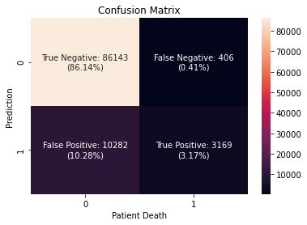

```python
def predict_death_2(x):
    return [1 if i >= 0.5 else 0 for i in model_2.predict(x)]

sample_testing_2["pred"] = predict_death_2(sample_testing_2)
tp, tn, fp, fn = confusion(sample_testing_2)
```

```python
error_rate = (fp + fn) / sample_testing_2.shape[0]
accuracy = 1 - error_rate
sensitivity = tp / (tp + fn)
specificity = tn / (tn + fp)
metrics["New Model"] = [error_rate, accuracy, sensitivity, specificity]
metrics
```

|  | Initial Model | New Model |
| --- | --- | --- |
| Error Rate | 0.034100 | 0.106880 |
| Accuracy | 0.965900 | 0.893120 |
| Sensitivity | 0.111892 | 0.886434 |
| Specificity | 0.997397 | 0.893368 |

Our new model shows drastic improvement over the previous one. We now have an accuracy of 89% and very good sensitivity and specificity just by using better training data! We have a high rate of false positives; however, it seems to be consistent across runs. This means we may not be able to use the model to accurately predict individual deaths (or to be more precise, to accurately predict survivors), but by subtracting the suspected number of false positives, we may compute the aggregate quantity of possible missing deaths.

About that multicollinearity, should it pop up as a warning: It means many of the variables we chose are closely correlated. Linear regression tends to break down in this case as it assumes no multicollinearity. Because most of our variables are categorical, there is really no way around this - the CDC just doesn't give us enough independent variables. This is a limitation of the data, unfortunately - [note that it is only a problem if you need accurate coefficients and p-values](https://statisticsbyjim.com/regression/multicollinearity-in-regression-analysis/). In our case, we are only trying to make predictions; therefore, we do not.

Let's try to count potential missing deaths in a random sample of patients. We will start by taking the sample, of course.

```python
sample_predict = rebuild(covid19.sample(100000))
```

Now let's generate some predictions for these patients.

```python
sample_predict["pred"] = predict_death_2(sample_predict)

known_deaths = sample_predict.death_Yes.sum()
pred_known_deaths = sample_predict[(sample_predict.death_Yes == 1) | (sample_predict.death_No == 1)].pred.sum()
predicted_deaths = sample_predict[(sample_predict.death_Unknown == 1)\
                                  | (sample_predict.death_Missing == 1)].pred.sum()
```

We'll make a pretty chart too. There is no built-in way to label our bars so we must do it manually.

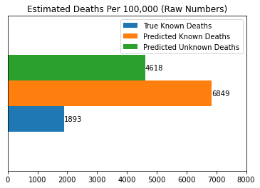

```python
deaths = pd.DataFrame([[known_deaths, pred_known_deaths, predicted_deaths]],\
                      columns = ["True Known Deaths", "Predicted Known Deaths", "Predicted Unknown Deaths"])

plot = deaths.plot.barh()
plt.yticks([])
plt.xticks([0, 1000, 2000, 3000, 4000, 5000, 6000, 7000, 8000])

bars = plot.patches
for bar, label in zip(bars, [known_deaths, pred_known_deaths, predicted_deaths]):
    width = bar.get_width()
    plot.text(width, bar.get_y() + bar.get_height() / 2, label, ha='left', va='center')

plt.title("Estimated Deaths Per 100,000 (Raw Numbers)")
plt.show()
```

The raw numbers seem a little preposterous. However, we can expect some number of those predicted deaths to be false positives and some number of predicted survivors to be false negatives. A confusion matrix will help us:

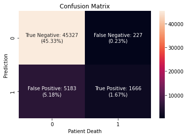

```python
true_positive, true_negative, false_positive, false_negative = confusion(sample_predict)
```

```python
false_positive_rate = false_positive / (false_positive + true_positive)
false_negative_rate = false_negative / (false_negative + true_negative)

pred_known_surv = sample_predict[((sample_predict.death_Yes == 1) | (sample_predict.death_No == 1)\
                                  & (sample_predict.pred == 0))].shape[0]
pred_unknown_surv = sample_predict[((sample_predict.death_Unknown == 1) | (sample_predict.death_Missing == 1)\
                                    & (sample_predict.pred == 0))].shape[0]

est_known_deaths = pred_known_deaths - (pred_known_deaths * false_positive_rate)\
                                     + (pred_known_surv * false_negative_rate)

est_unknown_deaths = predicted_deaths - (predicted_deaths * false_positive_rate)\
                                     + (pred_unknown_surv * false_negative_rate)
```

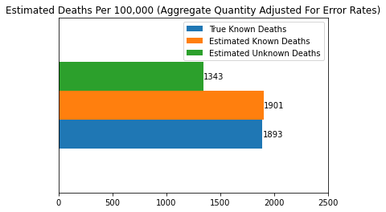

```
Estimated real deaths: 1.7x reported deaths
```

```python
deaths = pd.DataFrame([[known_deaths, est_known_deaths, est_unknown_deaths]],\
                      columns = ["True Known Deaths", "Estimated Known Deaths", "Estimated Unknown Deaths"])

plot = deaths.plot.barh()
plt.yticks([])
plt.xticks([0, 500, 1000, 1500, 2000, 2500])

bars = plot.patches
for bar, label in zip(bars, [known_deaths, round(est_known_deaths), round(est_unknown_deaths)]):
    width = bar.get_width()
    plot.text(width, bar.get_y() + bar.get_height() / 2, label, ha='left', va='center')

plt.title("Estimated Deaths Per 100,000 (Aggregate Quantity Adjusted For Error Rates)")
plt.show()

print("Estimated real deaths: " +\
      str(round((est_known_deaths + est_unknown_deaths) / est_known_deaths, 1)) +\
      "x reported deaths")
```

## Conclusion

We also produced a useful, albeit simplistic, model for screening COVID-19 patients' risk. Because the CDC's data does not include enough independent variables, our model relies too heavily on age and has a high false-positive rate. Finding a better dataset and repeating this process is left as an exercise to the reader. It might be worth checking out [this study that predicted COVID-19 deaths using a set of very detailed information about each case](https://www.nature.com/articles/s41598-020-75767-2). In theory, our model would still be clinically useful in predicting at-risk patients as its sensitivity is quite high, and it does illustrate how statistical modeling/machine learning could be useful in medicine to assess risk. But sometimes in data science, the only answer is that you don't have the information you need. Keep your eyes peeled, you'll find it eventually!

Finally: **Stay out of my data!** If you haven't already, **get a COVID-19 vaccine today,** and if you have, help out your friends and family! I got mine recently and had minimal side effects, only a few slight aches after the second dose that went away within 24 hours. It's a small sacrifice to keep yourself safe from a disease that has maimed and killed so many, and it's how we will beat this virus. A quick google search for "covid vaccine finder" should start you in the right direction.